# LS16 Hyne Tumbarumba Data for Stan

> For each test log:
> - Stress Wave Velocity
> - SED, LED, Length
> - Sweep
> - Principal
> - Orthogonal
> - % heartwood
> - Large end
> - Small end
> - Taper and “waist from a quadratic fit to polygonal area” (not sure what that waist parameter is)
> - Whorl-i-ness

```r
library(RODBC)
library(RODBC)
ch = odbcConnect('Hyne',uid='sa',pwd="password12")
sql = "select
  p.SWILogNumber as SWILogNumber,
  t.SWV as [SWV.hitman],
  t.LED as [LED.yard],
  t.SED as [SED.yard],
  t.length as Length,
  t.weight [log.weight],
  p.volume,
  p.m_sweep1 as SweepPrincipal,
  p.m_sweep2 as SweepOrthogonal,
  p.m_taper as Taper,
  p.m_waist as Waist,
  p.m_whorliness as Whorliness,
  (rL*rL*1e6)/(t.LED*t.LED/4)*100 as LEheartPercent,
  (rS*rS*1e6)/(t.SED*t.SED/4)*100 as SEheartPercent,
  3.141592654*4.9/3*(rL*rL+rS*rL+rS*rS) as [volume.heart],
  q.nboards*4.9*0.0905*0.0349/p.volume as vfracRecovered,
  q.abc_avg as ABC
from
  (select *
     from logs
   where SWILogNumber is not null
   and DateAndTime>'2014-08-31 00:00:00') p
left join (select *
             from logs
             where SWILogNumber is not null
             and DateAndTime<'2014-08-31 00:00:00') s
  on s.SWILogNumber=p.SWILogNumber
left join yardTrimmed t
  on p.SWILogNumber=t.SWILogNumber
left join yardUntrimmed u
  on p.SWILogNumber=u.SWILogNumber
left join (select
             l.SWILogNumber,
             l.heartwoodDiameter_mm/2000 rL,
             s.heartwoodDiameter_mm/2000 rS
           from
             logends l,
             logends s
           where
             s.SWILogNumber=l.SWILogNumber
             and s.logEnd='S'
             and l.logEnd='L') h
  on h.SWILogNumber=p.SWILogNumber
left join tmp_logquality q on q.SWILogNumber=p.SWILogNumber
order by p.SWILogNumber"
L = sqlQuery(ch,sql)
write.csv(L, row.names=FALSE, quote=FALSE, file="/home/harrinjj/Desktop/Dropbox/4stan/hyne-logs.csv")
```

Inner ten ring area not available for hyne logs. If needed, can be derived from log end images.

All trial logs were trimmed to 4.9m, some from the small end some from the large. The SWV is that measured using Hitman on the trimmed log.

> Log shape data every 6” along the length (scanner resolution)
> - Diameter (polygonal)
> - Eliptical shape
> - Major diameter
> - Minor diameter
> - Orientation of major diameter (degrees) relative to a fixed coordinate system
> - Ovality
> - Area (polygonal)

See `hyne-xsectns.csv` in dropbox folder. Generated by `logmetrics.Rmd` and `USNR/reprocess.py`. The shape data used is from the ELI scanner, whereas the summary data above comes from the ROY scanner. There will be small differences.

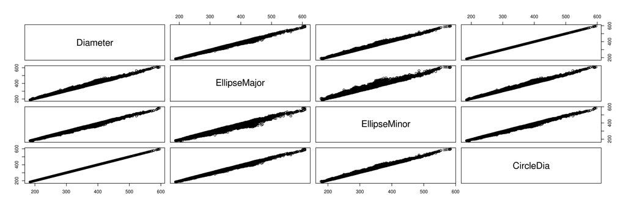

```r
library(lattice)
X = read.csv('/home/harrinjj/Desktop/Dropbox/4stan/hyne-xsectns.csv')
#str(X)
pairs(X[,c('Diameter','EllipseMajor','EllipseMinor','CircleDia')])
```

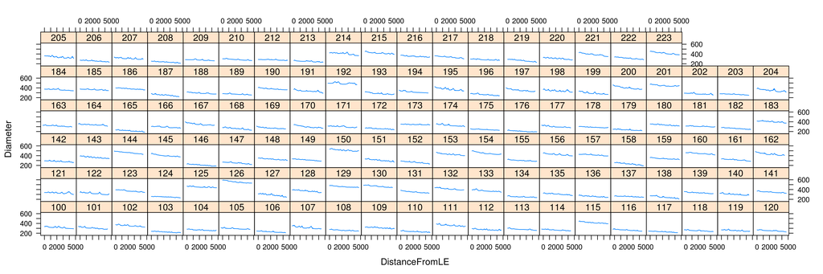

```r
xyplot(Diameter ~ DistanceFromLE | as.factor(SWILogNumber), X, type="l")
```

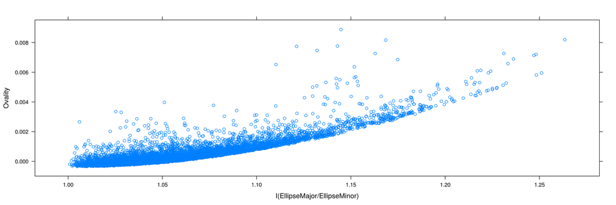

```r
xyplot(Ovality ~ I(EllipseMajor/EllipseMinor), X)
```

> For each piece of lumber sawn from the log
> - log id
> - Length
> - Width
> - Thickness
> - Warp (signed twist, crook, bow)
> - MOE
> - Density
> - Visual Grade
> - Whether inner or outer
> - MC at time warp data obtained

```r
B = sqlQuery(ch, "
             select
                m.flitchId,
                SWILogNumber,
                m.swv [swv.hitman_m/s],
                m.pith,
                m.wane,
                m.inCant,
                m.bow bow_mm,
                m.crook crook_mm,
                m.twist twist_mm,
                m.mc [MC%],
                X_Dens [density_kg/m3],
                O_Width/10 as width_mm,
                O_Thick/10 as thick_mm,
                O_Len as length_mm,
                xc, yc
             from (
                select
                  flitchId,
                  max(pith) pith,
                  max(wane) wane,
                  avg(swv) swv,
                  avg(bow) bow,
                  avg(crook) crook,
                  avg(twist) twist,
                  max(inCant) inCant,
                  avg(mc) mc
                from manualMeas group by flitchId
             ) m
             left join CHHBoards c on c.flitchId=m.flitchId
             left join HyneDryBoards h on h.flitchId=m.flitchId
             left join ecoustic g on m.flitchId=g.flitchId
             left join (
                select
                  flitchId,
                  max(SWILogNumber) SWILogNumber
                from
                  boardEndImages i, barcode_image bi, boardEndBarcodes b
                where flitchId is not null and i.id=bi.imageId and bi.barcodeId=b.id group by flitchId
             ) f on f.flitchId=m.flitchId
             left join (
                select FlitchID, avg(boardCentroidX_mm) xc, avg(boardCentroidY_mm) yc
                from boardEndBarcodes b, boardEndImages i, barcode_image bi
                where b.id=bi.barcodeId and i.id=bi.imageId
                group by FlitchID
             ) xy on xy.FlitchID=m.flitchId
             ")
B$moe_GPa = B$swv.hitman^2*B$density/1e9
B$R_mm = sqrt(B$xc^2 + B$yc^2)
B$kappa.z = 8*B$crook / (4.9)^2
B$kappa.y = 8*B$bow / (4.9)^2
B$abc = sqrt(B$kappa.z^2 + B$kappa.y^2)
write.csv(B, row.names=FALSE, quote=FALSE, file="/home/harrinjj/Desktop/Dropbox/4stan/hyne-boards.csv")
```

The board data is from the manual measurements or the from the mill data collected at CHH Tumut.

Warp was assessed only for nominal 90x40 boards (some of which had varying amounts of wane).

Visual grade was never assessed. I’ve not labelled boards inner or outer, but have included distance from the pith (R, mm). Distance from the pith was only assessed on large end, and since all the logs in the study are butt logs, the pith wander near the large end characteristic of such logs probably limits the representativeness of these distances.

Moisture content was measured on only a few boards using a Wagner resistance meter.

> Data associated with the Stand the log came from (if available)
> - Age
> - Average DBH (or stem LED) i.e. any way of knowing whether the stem associated with a test log was above or below average size for the stand

All we have is the “DA” identifier. Trial logs came from 5 sources (H0100, S0003, S0005, S0015, S0088) but the majority came from H0100 (49 logs) and S0015 (50 logs).

> Did you collect any acoustic or shape data on the stem from which the test log was taken – or from any of the upper logs taken from the same stem? If so, some summary statistics would be helpful.

No stem information available.